# Praticum III

Jacqueline Der and Soumeng Chea

## Part 1

### Part 1.1

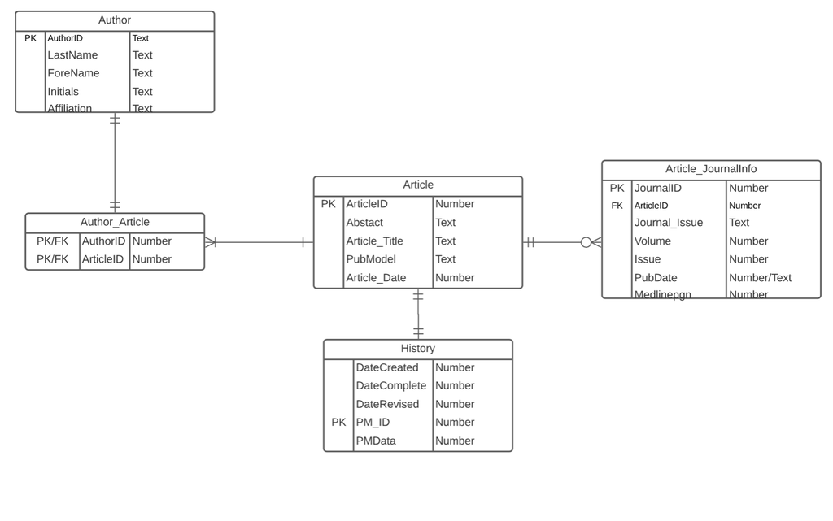

Entities Relationship Diagram for Article, Journal, Author, History

### Part 1.2

```r
library(RSQLite)
library(DBI)

med <- dbConnect(RSQLite::SQLite(), "pubmed.db")

dbSendStatement(med, statement = "create table if not exists author(
                authorID INT NOT NULL,
                lastName TEXT NULL,
                foreName Text NULL,
                initial TEXT NULL,
                affiliation text NULL, PRIMARY KEY(authorID));")
```

```
<SQLiteResult>
  SQL  create table if not exists author(
                authorID INT NOT NULL,
                lastName TEXT NULL,
                foreName Text NULL,
                initial TEXT NULL,
                affiliation text NULL, PRIMARY KEY(authorID));
  ROWS Fetched: 0 [complete]
       Changed: 0
```

```r
dbSendStatement(med, statement = "create table if not exists author_article(
                authorID INT NOT NULL,
                articleID INT NOT NULL,
                PRIMARY KEY(authorID, articleID)
                FOREIGN KEY (authorID) references author(authorID)
                FOREIGN KEY (articleID) references article(articleID));")
```

```
<SQLiteResult>
  SQL  create table if not exists author_article(
                authorID INT NOT NULL,
                articleID INT NOT NULL,
                PRIMARY KEY(authorID, articleID)
                FOREIGN KEY (authorID) references author(authorID)
                FOREIGN KEY (articleID) references article(articleID));
  ROWS Fetched: 0 [complete]
       Changed: 0
```

```r
dbSendStatement(med, statement = "create table if not exists article(
                pmID INT NOT NULL,
                doi TEXT NULL,
                abstract TEXT NULL,
                articleTitle TEXT NULL,
                pubModel TEXT null,
                pubYear TEXT null,
                pubMonth TEXT null,
                primary key (pmID));")
```

```
<SQLiteResult>
  SQL  create table if not exists article(
                pmID INT NOT NULL,
                doi TEXT NULL,
                abstract TEXT NULL,
                articleTitle TEXT NULL,
                pubModel TEXT null,
                pubYear TEXT null,
                pubMonth TEXT null,
                primary key (pmID));
  ROWS Fetched: 0 [complete]
       Changed: 0
```

```r
dbSendStatement(med, statement = "create table if not exists article_journal(
                journalID INT NOT NULL,
                articleID INT NOT NULL,
                volume INT null,
                issue INT null,
                medLinePGN INT NULL,
                primary key (journalID, articleID)
                FOREIGN KEY (articleID) references article(articleID));")
```

```
<SQLiteResult>
  SQL  create table if not exists article_journal(
                journalID INT NOT NULL,
                articleID INT NOT NULL,
                volume INT null,
                issue INT null,
                medLinePGN INT NULL,
                primary key (journalID, articleID)
                FOREIGN KEY (articleID) references article(articleID));
  ROWS Fetched: 0 [complete]
       Changed: 0
```

```r
dbSendStatement(med, statement = "create table if not exists journal(
                journalID INT NOT NULL,
                issn TEXT not null,
                issnType TEXT NULL,
                journal text NULL,
                primary key (journalID));")
```

```
<SQLiteResult>
  SQL  create table if not exists journal(
                journalID INT NOT NULL,
                issn TEXT not null,
                issnType TEXT NULL,
                journal text NULL,
                primary key (journalID));
  ROWS Fetched: 0 [complete]
       Changed: 0
```

```r
dbSendStatement(med, statement = "create table if not exists history(
                pmID INT not null,
                dateCreated INT NULL,
                dateComplete INT null,
                dateRevised INT null,
                pmData INT null, primary key (pmID));")
```

```
<SQLiteResult>
  SQL  create table if not exists history(
                pmID INT not null,
                dateCreated INT NULL,
                dateComplete INT null,
                dateRevised INT null,
                pmData INT null, primary key (pmID));
  ROWS Fetched: 0 [complete]
       Changed: 0
```

```r
# drop table statements to clear tables
#dbExecute(med, "DROP TABLE IF EXISTS author;")
#dbExecute(med, "DROP TABLE IF EXISTS author_article;")
#dbExecute(med, "DROP TABLE IF EXISTS article;")
#dbExecute(med, "DROP TABLE IF EXISTS article_journal;")
#dbExecute(med, "DROP TABLE IF EXISTS history;")
```

### Part 1.3

##### Parse PubMed XML file

```r
#install.packages("data.table")
#install.packages("tidyverse")
library(XML)
library(dplyr)
library(tidyr)
library(data.table)
library(tidyverse)


path <- "/Users/soumengchea/Desktop/"
fn <- "pubmed_sample.xml"
fpn = paste0(path, fn)

# Reading the XML file and parse into DOM
xml_data <- xmlParse(file = fpn)
nodes <- getNodeSet(xml_data, "//PubmedArticle")

xmlRoot <- xmlRoot(xml_data)

# Get the name of the node
xmlName(xmlRoot)
```

```
[1] "PubmedArticleSet"
```

```r
# Get the number of nodes in root
xmlSize(xmlRoot)
```

```
[1] 19
```

##### Get author last name, first name, initials and affilication

```r
# get pmid
pmid <- xpathSApply(xml_data,"//MedlineCitation/PMID", xmlValue)

# get author last names
last_name <- lapply(nodes, xpathSApply, ".//Author/LastName", xmlValue)
last_name[sapply(last_name, is.list)] <- NA

# get author first names
first_name <- lapply(nodes, xpathSApply, ".//Author/ForeName", xmlValue)
first_name[sapply(first_name, is.list)] <- NA

# get author initials
init <- lapply(nodes, xpathSApply, ".//Author/Initials", xmlValue)
init[sapply(init, is.list)] <- NA

#   combine authors together
authors <- mapply(paste, last_name, first_name, init, collapse = ",")
authors <- as.character(authors)

# get affiliations for all authors, apply NA for authors without affiliation
affiliation<-xpathSApply(xml_data, "//Author", function(x) {
  author_affiliation <- xmlValue(x[["Affiliation"]])})
affiliation[sapply(affiliation, is.list)] <- NA

# write authors to dataframe, then separate authors (to associate with correct pmid)
df_author <- data.frame(pmid, authors, stringsAsFactors = FALSE)
df_author <- df_author  %>% mutate(authors = strsplit(authors, ",")) %>% unnest(authors)

# add affiliation to dataframe and replace NAs with empty strings
df_author$affiliation <- affiliation
nas <- which(is.na(df_author[,3]))
df_author[nas,3] <- " "


# split author name to last name, first name, initial
df_author <- df_author %>% separate(authors, c("name", "init"), sep="\\s+(?=\\S*$)")
df_author <- df_author %>% separate(name, c("last_name", "first_name"), sep="\\s", extra = "merge")
```

```r
dbExecute(med, "BEGIN TRANSACTION;")
```

```
[1] 0
```

```r
dbExecute(med, "DROP TABLE IF EXISTS temp;")
```

```
[1] 0
```

```r
dbExecute(med, "DROP TABLE IF EXISTS temp_author;")
```

```
[1] 0
```

```r
dbWriteTable(med, "temp", df_author)

dbSendStatement(med, statement = "create table if not exists temp_author(
                authorID INTEGER NOT NULL PRIMARY KEY AUTOINCREMENT,
                lastName TEXT NULL,
                foreName Text NULL,
                initial TEXT NULL,
                affiliation text NULL,
                articleID INT NOT NULL);")
```

```
<SQLiteResult>
  SQL  create table if not exists temp_author(
                authorID INTEGER NOT NULL PRIMARY KEY AUTOINCREMENT,
                lastName TEXT NULL,
                foreName Text NULL,
                initial TEXT NULL,
                affiliation text NULL,
                articleID INT NOT NULL);
  ROWS Fetched: 0 [complete]
       Changed: 0
```

```r
dbSendStatement(med, "INSERT INTO temp_author SELECT null, last_name, first_name, init, affiliation, pmid FROM temp;")
```

```
<SQLiteResult>
  SQL  INSERT INTO temp_author SELECT null, last_name, first_name, init, affiliation, pmid FROM temp;
  ROWS Fetched: 0 [complete]
       Changed: 136
```

```r
dbSendStatement(med, "INSERT INTO author select authorID, lastName, foreName, initial, affiliation FROM temp_author;")
```

```
Error: UNIQUE constraint failed: author.authorID
```

##### Get article doi, pub model, abstract, title

```r
# get pmid
pmid <- xpathSApply(xml_data, "//MedlineCitation/PMID", xmlValue)

pubmodel <- xpathSApply(xml_data, "//MedlineCitation/Article", xmlAttrs)

doi <- lapply(nodes, xpathSApply, ".//ELocationID[@EIdType = \"doi\"]", xmlValue)
doi[sapply(doi, is.list)] <- NA
doi <- unlist(doi)

abstract <- lapply(nodes, xpathSApply, ".//Abstract/AbstractText", xmlValue)
abstract[sapply(abstract, is.list)] <- NA
abstract <- sapply(abstract, paste, collapse = "|")

title <- lapply(nodes, xpathSApply, ".//ArticleTitle", xmlValue)
title[sapply(title, is.list)] <- NA
title <- unlist(title)


df_article <- data.frame(pmid, doi, pubmodel, abstract, title, stringsAsFactors = FALSE)
```

##### Get the dates created, completed, revised

```r
# get date created
year_created <- lapply(nodes, xpathSApply, ".//MedlineCitation/DateCreated/Year", xmlValue)
year_created[sapply(year_created, is.list)] <- NA
month_created <- lapply(nodes, xpathSApply, ".//MedlineCitation/DateCreated/Month", xmlValue)
month_created[sapply(month_created, is.list)] <- NA
day_created <- lapply(nodes, xpathSApply, ".//MedlineCitation/DateCreated/Day", xmlValue)
day_created[sapply(day_created, is.list)] <- NA
created <- mapply(paste, year_created, month_created, day_created, collapse = "")
created[created == ""]<- NA

# get date completed
year_completed <- lapply(nodes, xpathSApply, ".//MedlineCitation/DateCompleted/Year", xmlValue)
year_completed[sapply(year_completed, is.list)] <- NA
month_completed <- lapply(nodes, xpathSApply, ".//MedlineCitation/DateCompleted//Month", xmlValue)
month_completed[sapply(as.numeric(month_completed), is.list)] <- NA
day_completed <- lapply(nodes, xpathSApply, ".//MedlineCitation/DateCompleted/Day", xmlValue)
day_completed[sapply(day_completed, is.list)] <- NA
completed <- mapply(paste, year_completed, month_completed, day_completed, collapse = "")
completed[completed == ""]<- NA

# get date revised
year_revised <- lapply(nodes, xpathSApply, ".//MedlineCitation/DateCompleted/Year", xmlValue)
year_revised[sapply(year_revised, is.list)] <- NA
month_revised <- lapply(nodes, xpathSApply, ".//MedlineCitation/DateCompleted//Month", xmlValue)
month_revised[sapply(month_revised, is.list)] <- NA
day_revised <- lapply(nodes, xpathSApply, ".//MedlineCitation/DateCompleted/Day", xmlValue)
day_revised[sapply(day_revised, is.list)] <- NA
revised <- mapply(paste, year_revised, month_revised, day_revised, collapse = "")
revised[revised == ""]<- NA

# format date created
df_article$date_created <- created
df_article$date_created <- sub(" ", "-", df_article$date_created)
df_article$date_created <- sub(" ", "-", df_article$date_created)

# format date completed
df_article$date_completed <- completed
df_article$date_completed <- sub(" ", "-", df_article$date_completed)
df_article$date_completed <- sub(" ", "-", df_article$date_completed)

# format date revised
df_article$date_revised <- revised
df_article$date_revised <- sub(" ", "-", df_article$date_revised)
df_article$date_revised <- sub(" ", "-", df_article$date_revised)

# add pub year and pub month
pub_year <- lapply(nodes, xpathSApply, ".//Journal/JournalIssue/PubDate/Year", xmlValue)
pub_year[sapply(pub_year, is.list)] <- NA
pub_year <- unlist(pub_year)
df_article$pub_year <- pub_year
nas <- which(is.na(df_article[,9]))
df_article[nas,9] <- " "

pub_month <- lapply(nodes, xpathSApply, ".//Journal/JournalIssue/PubDate/Month", xmlValue)
pub_month[sapply(pub_month, is.list)] <- NA
pub_month <- unlist(pub_month)
df_article$pub_month <- pub_month
nas <- which(is.na(df_article[,10]))
df_article[nas,10] <- " "
```

```r
dbExecute(med, "BEGIN TRANSACTION;")
```

```
[1] 0
```

```r
dbExecute(med, "DROP TABLE IF EXISTS temp_article;")
```

```
[1] 0
```

```r
dbWriteTable(med, "temp_article", df_article)
dbSendStatement(med, "INSERT INTO article SELECT pmid, doi, abstract, title, pubmodel, pub_year, pub_month FROM temp_article;")
```

```
<SQLiteResult>
  SQL  INSERT INTO article SELECT pmid, doi, abstract, title, pubmodel, pub_year, pub_month FROM temp_article;
  ROWS Fetched: 0 [complete]
       Changed: 19
```

```r
dbExecute(med, "COMMIT;")
```

```
[1] 0
```

```r
dbExecute(med, "BEGIN TRANSACTION;")
```

```
[1] 0
```

```r
dbSendStatement(med, "INSERT INTO history SELECT pmid, date_created, date_completed, date_revised, null FROM temp_article;")
```

```
<SQLiteResult>
  SQL  INSERT INTO history SELECT pmid, date_created, date_completed, date_revised, null FROM temp_article;
  ROWS Fetched: 0 [complete]
       Changed: 19
```

```r
dbExecute(med, "COMMIT;")
```

```
[1] 0
```

#### Get the article journal

```r
pmid <- xpathSApply(xml_data, "//MedlineCitation/PMID", xmlValue)

issn_type <- xpathSApply(xml_data, "//Article/Journal/ISSN", xmlAttrs)
issn <- lapply(nodes, xpathSApply, ".//Article/Journal/ISSN", xmlValue)
issn <- unlist(issn)
#
journal <- lapply(nodes, xpathSApply, ".//ISOAbbreviation", xmlValue)
journal[sapply(journal, is.list)] <- NA
journal <- unlist(journal)


# medline citation->article->journal->journalissue
volume <- lapply(nodes, xpathSApply, ".//JournalIssue/Volume", xmlValue)
volume[sapply(volume, is.list)] <- NA
volume <- unlist(volume)


issue <- lapply(nodes, xpathSApply, ".//JournalIssue/Issue", xmlValue)
issue[sapply(issue, is.list)] <- NA
issue <- unlist(issue)

# medline citation->article->pagination
pages <- lapply(nodes, xpathSApply, ".//MedlinePgn", xmlValue)
pages[sapply(pages, is.list)] <- NA
pages <- unlist(pages)

df_journal <- data.frame(issn, pmid, issn_type, journal, volume, issue, pages, stringsAsFactors = FALSE)
```

```r
dbExecute(med, "BEGIN TRANSACTION;")
```

```
[1] 0
```

```r
dbExecute(med, "DROP TABLE IF EXISTS temp;")
```

```
[1] 0
```

```r
dbExecute(med, "DROP TABLE IF EXISTS temp_journal;")
```

```
[1] 0
```

```r
dbWriteTable(med, "temp", df_journal)

dbSendStatement(med, statement = "create table if not exists temp_journal(
                journalID INTEGER NOT NULL PRIMARY KEY AUTOINCREMENT,
                issn TEXT not null,
                articleID INT NOT NULL,
                issnType TEXT NULL,
                journal text NULL,
                volume INT null,
                issue INT null,
                medLinePGN INT NULL,
                FOREIGN KEY (articleID) references article(articleID));")
```

```
<SQLiteResult>
  SQL  create table if not exists temp_journal(
                journalID INTEGER NOT NULL PRIMARY KEY AUTOINCREMENT,
                issn TEXT not null,
                articleID INT NOT NULL,
                issnType TEXT NULL,
                journal text NULL,
                volume INT null,
                issue INT null,
                medLinePGN INT NULL,
                FOREIGN KEY (articleID) references article(articleID));
  ROWS Fetched: 0 [complete]
       Changed: 0
```

```r
dbSendStatement(med, "INSERT INTO temp_journal SELECT null, issn, pmid, issn_type, journal, volume, issue, pages FROM temp;")
```

```
<SQLiteResult>
  SQL  INSERT INTO temp_journal SELECT null, issn, pmid, issn_type, journal, volume, issue, pages FROM temp;
  ROWS Fetched: 0 [complete]
       Changed: 19
```

```r
dbSendStatement(med, "INSERT INTO article_journal SELECT journalID, articleID, volume, issue, medLinePGN FROM temp_journal;")
```

```
<SQLiteResult>
  SQL  INSERT INTO article_journal SELECT journalID, articleID, volume, issue, medLinePGN FROM temp_journal;
  ROWS Fetched: 0 [complete]
       Changed: 19
```

```r
dbSendStatement(med, "INSERT INTO journal SELECT journalID, issn, issnType, journal FROM temp_journal")
```

```
<SQLiteResult>
  SQL  INSERT INTO journal SELECT journalID, issn, issnType, journal FROM temp_journal
  ROWS Fetched: 0 [complete]
       Changed: 19
```

```r
dbExecute(med, "COMMIT;")
```

```
[1] 0
```

## Part 2

### Part 2.1

#### Star Schema

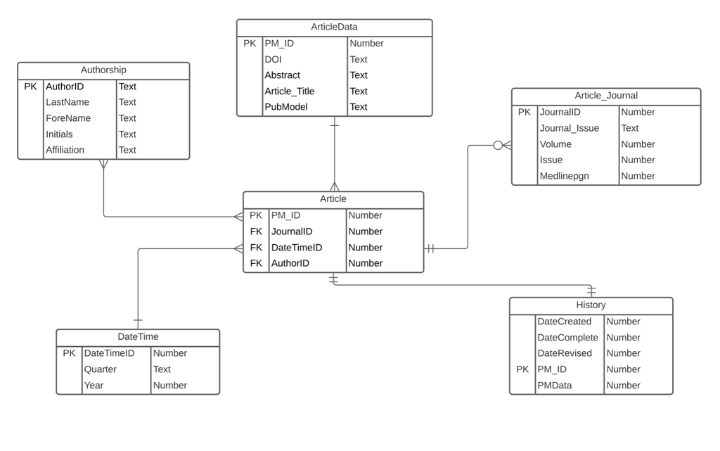

Entities Relationship Diagram for Article, Journal, Author, History

### Part 2.2

#### Star Schema with Article Fact Table

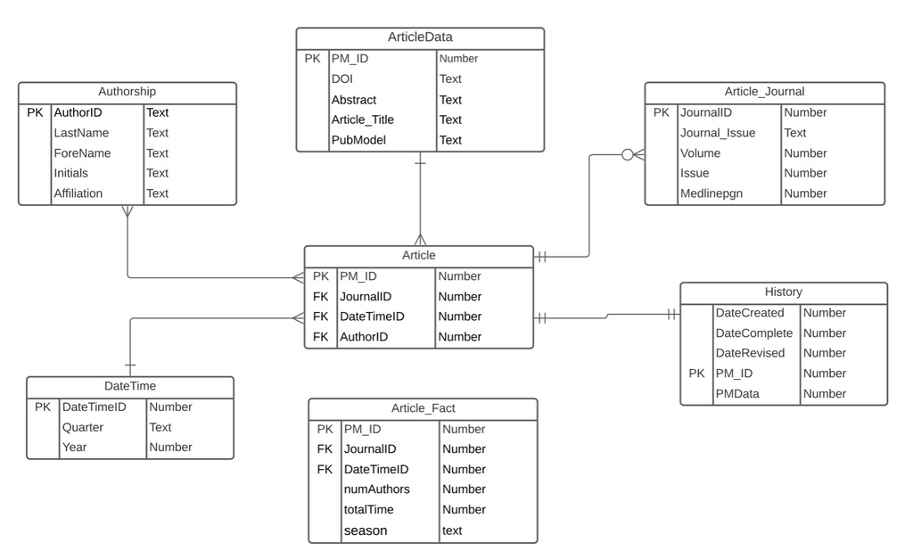

Entities Relationship Diagram for Article, Journal, Author, History

Create star schema tables

```r
pub <- dbConnect(RSQLite::SQLite(), "medstar.db")
```

```r
dbSendStatement(pub, statement = "create table if not exists articles(
                pmID INT NOT NULL,
                dateTimeID INT Not NULL,
                authorID INT NOT NULL,
                pubJournalID INT,
                foreign key (dateTimeID) references dateTime(dateTimeID)
                foreign key (authorID) references author(authorID)
                foreign key (pubJournalID) references journal(journalID)
                primary key (pmID, authorID));")
```

```
<SQLiteResult>
  SQL  create table if not exists articles(
                pmID INT NOT NULL,
                dateTimeID INT Not NULL,
                authorID INT NOT NULL,
                pubJournalID INT,
                foreign key (dateTimeID) references dateTime(dateTimeID)
                foreign key (authorID) references author(authorID)
                foreign key (pubJournalID) references journal(journalID)
                primary key (pmID, authorID));
  ROWS Fetched: 0 [complete]
       Changed: 0
```

```r
dbSendStatement(pub, statement = "create table if not exists articleData(
                pmID INT not null,
                doi TEXT NULL,
                abstract TEXT NULL,
                articleTitle TEXT NULL,
                pubModel TEXT null,
                pubYear TEXT null,
                pubMonth TEXT null,
                primary key (pmID));")
```

```
<SQLiteResult>
  SQL  create table if not exists articleData(
                pmID INT not null,
                doi TEXT NULL,
                abstract TEXT NULL,
                articleTitle TEXT NULL,
                pubModel TEXT null,
                pubYear TEXT null,
                pubMonth TEXT null,
                primary key (pmID));
  ROWS Fetched: 0 [complete]
       Changed: 0
```

```r
dbSendStatement(pub, statement = "create table if not exists author(
                authorID NOT NULL,
                lastName TEXT NULL,
                foreName Text NULL,
                initial TEXT NULL,
                affiliation text NULL,
                PRIMARY KEY(authorID));")
```

```
<SQLiteResult>
  SQL  create table if not exists author(
                authorID NOT NULL,
                lastName TEXT NULL,
                foreName Text NULL,
                initial TEXT NULL,
                affiliation text NULL,
                PRIMARY KEY(authorID));
  ROWS Fetched: 0 [complete]
       Changed: 0
```

```r
dbSendStatement(pub, statement = "create table if not exists history(
                pmID INT not null,
                dateCreated INT NULL,
                dateComplete INT null,
                dateRevised INT null,
                pmData INT null,
                primary key (pmID));")
```

```
<SQLiteResult>
  SQL  create table if not exists history(
                pmID INT not null,
                dateCreated INT NULL,
                dateComplete INT null,
                dateRevised INT null,
                pmData INT null,
                primary key (pmID));
  ROWS Fetched: 0 [complete]
       Changed: 0
```

```r
dbSendStatement(pub, statement = "create table if not exists article_journal(
                journalID INT not null PRIMARY KEY,
                volume INT null,
                issue INT null,
                medLinePGN INT NULL);")
```

```
<SQLiteResult>
  SQL  create table if not exists article_journal(
                journalID INT not null PRIMARY KEY,
                volume INT null,
                issue INT null,
                medLinePGN INT NULL);
  ROWS Fetched: 0 [complete]
       Changed: 0
```

```r
dbSendStatement(med, statement = "create table if not exists journalInfo(
                journalID INT NOT NULL,
                issn TEXT not null,
                issnType TEXT NULL,
                journal text NULL,
                primary key (journalID));")
```

```
<SQLiteResult>
  SQL  create table if not exists journalInfo(
                journalID INT NOT NULL,
                issn TEXT not null,
                issnType TEXT NULL,
                journal text NULL,
                primary key (journalID));
  ROWS Fetched: 0 [complete]
       Changed: 0
```

```r
dbSendStatement(pub, statement = "Create table if not exists dateTime(
                dateTimeID INTEGER not null PRIMARY KEY AUTOINCREMENT,
                quarter TEXT null,
                year INT null);")
```

```
<SQLiteResult>
  SQL  Create table if not exists dateTime(
                dateTimeID INTEGER not null PRIMARY KEY AUTOINCREMENT,
                quarter TEXT null,
                year INT null);
  ROWS Fetched: 0 [complete]
       Changed: 0
```

```r
dbSendStatement(pub, statement = "Create table if not exists article_fact(
                pmID INT not null,
                pubJournalID INT not null,
                numAuthors INT,
                timeToComplete INT,
                season TEXT);")
```

```
<SQLiteResult>
  SQL  Create table if not exists article_fact(
                pmID INT not null,
                pubJournalID INT not null,
                numAuthors INT,
                timeToComplete INT,
                season TEXT);
  ROWS Fetched: 0 [complete]
       Changed: 0
```

```r
dbSendStatement(pub, "ATTACH DATABASE 'pubmed.db' AS pubmed;")
```

```
<SQLiteResult>
  SQL  ATTACH DATABASE 'pubmed.db' AS pubmed;
  ROWS Fetched: 0 [complete]
       Changed: 0
```

```r
dbSendStatement(pub, "ATTACH DATABASE 'medstar.db' as star;")
```

```
<SQLiteResult>
  SQL  ATTACH DATABASE 'medstar.db' as star;
  ROWS Fetched: 0 [complete]
       Changed: 0
```

```r
# drop table statements to clear tables
#dbExecute(pub, "DROP TABLE IF EXISTS author;")
#dbExecute(pub, "DROP TABLE IF EXISTS author_article;")
#dbExecute(pub, "DROP TABLE IF EXISTS article;")
#dbExecute(pub, "DROP TABLE IF EXISTS article_journal;")
#dbExecute(pub, "DROP TABLE IF EXISTS history;")
```

Star Schema: author

```r
dbExecute(pub, "BEGIN TRANSACTION;")
```

```
[1] 0
```

```r
dbSendStatement(pub, "INSERT INTO star.author SELECT authorID, lastName, foreName, initial, affiliation FROM pubmed.temp_author;")
```

```
<SQLiteResult>
  SQL  INSERT INTO star.author SELECT authorID, lastName, foreName, initial, affiliation FROM pubmed.temp_author;
  ROWS Fetched: 0 [complete]
       Changed: 136
```

```r
dbExecute(pub, "COMMIT;")
```

```
[1] 0
```

Star Schema: history

```r
dbExecute(pub, "BEGIN TRANSACTION;")
```

```
[1] 0
```

```r
dbSendStatement(pub, "INSERT INTO star.history SELECT pmid, date_created, date_completed, date_revised, null FROM pubmed.temp_article;")
```

```
<SQLiteResult>
  SQL  INSERT INTO star.history SELECT pmid, date_created, date_completed, date_revised, null FROM pubmed.temp_article;
  ROWS Fetched: 0 [complete]
       Changed: 19
```

```r
dbExecute(pub, "COMMIT;")
```

```
[1] 0
```

Star Schema: article_journal

```r
dbExecute(pub, "BEGIN TRANSACTION;")
```

```
[1] 0
```

```r
dbSendStatement(pub, "INSERT INTO star.article_journal SELECT journalID, volume, issue, medLinePGN from pubmed.temp_journal;")
```

```
<SQLiteResult>
  SQL  INSERT INTO star.article_journal SELECT journalID, volume, issue, medLinePGN from pubmed.temp_journal;
  ROWS Fetched: 0 [complete]
       Changed: 19
```

```r
dbExecute(pub, "COMMIT;")
```

```
[1] 0
```

```r
dbExecute(pub, "BEGIN TRANSACTION;")
```

```
[1] 0
```

```r
dbSendStatement(pub, "INSERT INTO journalInfo SELECT journalID, issn, issnType, journal FROM pubmed.temp_journal;")
```

```
<SQLiteResult>
  SQL  INSERT INTO journalInfo SELECT journalID, issn, issnType, journal FROM pubmed.temp_journal;
  ROWS Fetched: 0 [complete]
       Changed: 19
```

```r
dbExecute(pub, "COMMIT;")
```

```
[1] 0
```

Star Schema: articleData

```r
dbExecute(pub, "BEGIN TRANSACTION;")
```

```
[1] 0
```

```r
dbSendStatement(pub, "INSERT INTO star.articleData SELECT pmID, doi, abstract, articleTitle, pubModel, pubYear, pubMonth from pubmed.article;")
```

```
<SQLiteResult>
  SQL  INSERT INTO star.articleData SELECT pmID, doi, abstract, articleTitle, pubModel, pubYear, pubMonth from pubmed.article;
  ROWS Fetched: 0 [complete]
       Changed: 19
```

```r
dbExecute(pub, "COMMIT;")
```

```
[1] 0
```

Star Schema: dateTime

```r
dbExecute(pub, "BEGIN TRANSACTION;")
```

```
[1] 0
```

```r
dbExecute(pub, "DROP TABLE IF EXISTS star.temp_dateTime;")
```

```
[1] 0
```

```r
dbSendStatement(pub, statement = "Create table if not exists star.temp_dateTime(
                dateTimeID INTEGER not null PRIMARY KEY AUTOINCREMENT,
                pmID INT not null,
                quarter TEXT null,
                year TEXT null);")
```

```
<SQLiteResult>
  SQL  Create table if not exists star.temp_dateTime(
                dateTimeID INTEGER not null PRIMARY KEY AUTOINCREMENT,
                pmID INT not null,
                quarter TEXT null,
                year TEXT null);
  ROWS Fetched: 0 [complete]
       Changed: 0
```

```r
dbExecute(pub, "COMMIT;")
```

```
[1] 0
```

```r
dbExecute(pub, "BEGIN TRANSACTION;")
```

```
[1] 0
```

```r
dbSendStatement(pub, "INSERT INTO star.temp_dateTime SELECT null, pmID, dateCreated, dateCreated from pubmed.history;")
```

```
<SQLiteResult>
  SQL  INSERT INTO star.temp_dateTime SELECT null, pmID, dateCreated, dateCreated from pubmed.history;
  ROWS Fetched: 0 [complete]
       Changed: 19
```

```r
dbExecute(pub, "COMMIT;")
```

```
[1] 0
```

```r
dbExecute(pub, "BEGIN TRANSACTION;")
```

```
[1] 0
```

```r
dbSendStatement(pub, "UPDATE temp_dateTime SET quarter = strftime('%m', quarter), year = strftime('%Y', year);")
```

```
<SQLiteResult>
  SQL  UPDATE temp_dateTime SET quarter = strftime('%m', quarter), year = strftime('%Y', year);
  ROWS Fetched: 0 [complete]
       Changed: 19
```

```r
dbExecute(pub, "COMMIT;")
```

```
[1] 0
```

```r
dbExecute(pub, "BEGIN TRANSACTION;")
```

```
[1] 0
```

```r
dbSendStatement(pub, "INSERT INTO star.dateTime SELECT dateTimeID, quarter, year FROM star.temp_dateTime;")
```

```
<SQLiteResult>
  SQL  INSERT INTO star.dateTime SELECT dateTimeID, quarter, year FROM star.temp_dateTime;
  ROWS Fetched: 0 [complete]
       Changed: 19
```

```r
dbExecute(pub, "COMMIT;")
```

```
[1] 0
```

Start Schema: article

```r
dbExecute(pub, "BEGIN TRANSACTION;")
```

```
[1] 0
```

```r
dbSendStatement(pub, "INSERT INTO star.articles(pmID, dateTimeID, authorID) SELECT articleID, dateTimeID, authorID FROM pubmed.author_article JOIN temp_dateTime ON pubmed.author_article.articleID = temp_dateTime.pmID;")
```

```
<SQLiteResult>
  SQL  INSERT INTO star.articles(pmID, dateTimeID, authorID) SELECT articleID, dateTimeID, authorID FROM pubmed.author_article JOIN temp_dateTime ON pubmed.author_article.articleID = temp_dateTime.pmID;
  ROWS Fetched: 0 [complete]
       Changed: 136
```

```r
dbExecute(pub, "COMMIT;")
```

```
[1] 0
```

```r
dbExecute(pub, "BEGIN TRANSACTION;")
```

```
[1] 0
```

```r
dbSendStatement(pub, "UPDATE star.articles SET pubJournalID = (SELECT journalID FROM pubmed.article_journal WHERE star.articles.pmID = pubmed.article_journal.articleID);")
```

```
<SQLiteResult>
  SQL  UPDATE star.articles SET pubJournalID = (SELECT journalID FROM pubmed.article_journal WHERE star.articles.pmID = pubmed.article_journal.articleID);
  ROWS Fetched: 0 [complete]
       Changed: 136
```

```r
dbExecute(pub, "COMMIT;")
```

```
[1] 0
```

Fill in article_fact fact table, count number of authors per article

```r
dbExecute(pub, "BEGIN TRANSACTION;")
```

```
[1] 0
```

```r
dbSendStatement(pub, "INSERT INTO star.article_fact(pmID, pubJournalID, numAuthors) SELECT pmID, pubJournalID, COUNT(DISTINCT(authorID)) FROM star.articles GROUP BY pmID;")
```

```
<SQLiteResult>
  SQL  INSERT INTO star.article_fact(pmID, pubJournalID, numAuthors) SELECT pmID, pubJournalID, COUNT(DISTINCT(authorID)) FROM star.articles GROUP BY pmID;
  ROWS Fetched: 0 [complete]
       Changed: 19
```

```r
dbExecute(pub, "COMMIT;")
```

```
[1] 0
```

Update the time to completion in days

```r
dbExecute(pub, "BEGIN TRANSACTION;")
```

```
[1] 0
```

```r
dbSendStatement(pub, "UPDATE star.article_fact
SET timetoComplete = (Select Cast ((
    JulianDay(history.dateRevised) - JulianDay(history.dateCreated)
) As Integer) FROM star.history WHERE star.article_fact.pmID = star.history.pmID);")
```

```
<SQLiteResult>
  SQL  UPDATE star.article_fact
SET timetoComplete = (Select Cast ((
    JulianDay(history.dateRevised) - JulianDay(history.dateCreated)
) As Integer) FROM star.history WHERE star.article_fact.pmID = star.history.pmID);
  ROWS Fetched: 0 [complete]
       Changed: 19
```

```r
dbExecute(pub, "COMMIT;")
```

```
[1] 0
```

Update season of publication using date created

```r
dbExecute(pub, "BEGIN TRANSACTION;")
```

```
[1] 0
```

```r
dbSendStatement(pub, "UPDATE star.article_fact
set season =
(select strftime('%m', star.history.datecreated)
 from star.history
 where star.history.pmid = star.article_fact.pmID);")
```

```
<SQLiteResult>
  SQL  UPDATE star.article_fact
set season =
(select strftime('%m', star.history.datecreated)
 from star.history
 where star.history.pmid = star.article_fact.pmID);
  ROWS Fetched: 0 [complete]
       Changed: 19
```

```r
dbExecute(pub, "COMMIT;")
```

```
[1] 0
```

Update season of publication from month to season (e.g. Month 05 is changed to ‘Spring’)

```r
dbExecute(pub, "BEGIN TRANSACTION;")
```

```
[1] 0
```

```r
dbSendStatement(pub, "UPDATE star.article_fact
set season =
(CASE
    when CAST(season as integer) >= 12 then 'winter'
    when cast(season as integer) > 8 then 'fall'
    when cast(season as integer) > 5 then 'summer'
    when cast(season as integer) > 2 then 'spring'
    else 'winter'
end);")
```

```
<SQLiteResult>
  SQL  UPDATE star.article_fact
set season =
(CASE
    when CAST(season as integer) >= 12 then 'winter'
    when cast(season as integer) > 8 then 'fall'
    when cast(season as integer) > 5 then 'summer'
    when cast(season as integer) > 2 then 'spring'
    else 'winter'
end);
  ROWS Fetched: 0 [complete]
       Changed: 19
```

```r
dbExecute(pub, "COMMIT;")
```

```
[1] 0
```

## Part 3

### Part 3.1

Find number of publications per season

```r
pubs_per_season = dbSendQuery(pub, "SELECT COUNT(pmID) as 'Publications', season FROM star.article_fact GROUP BY season;")
df_pubs_per_season<-dbFetch(pubs_per_season)
```

Find total time spent (in days) on articles grouped by the season they were published

```r
time_per_season = dbSendStatement(pub, "SELECT SUM(timeToComplete) as 'Days', season FROM star.article_fact GROUP BY season;")
df_time_per_season<-dbFetch(time_per_season)
```

Find number of authors publishing per season

```r
author_per_season = dbSendStatement(pub, "SELECT SUM(numAuthors) as 'Authors', season FROM star.article_fact GROUP BY season;")
df_author_per_season<-dbFetch(author_per_season)
```

Find number of publications per season by author Mazumdar

```r
mazumdar = dbSendQuery(pub, "SELECT COUNT(star.articles.pmID) as 'Publications', season
                              FROM star.article_fact
                              JOIN star.articles on star.articles.pmID = star.article_fact.pmID
                              JOIN star.author on star.articles.authorID = star.author.authorID
                              WHERE star.author.lastName LIKE 'Mazumdar'
                              GROUP BY season;")
df_mazumdar<-dbFetch(mazumdar)
```

Find number days spent on publication per season by author Chiu

```r
chiu = dbSendQuery(pub, "SELECT SUM(timeToComplete) as 'Days', season
                              FROM star.article_fact
                              JOIN star.articles on star.articles.pmID = star.article_fact.pmID
                              JOIN star.author on star.articles.authorID = star.author.authorID
                              WHERE star.author.lastName LIKE 'Chiu'
                              GROUP BY season;")
df_chiu<-dbFetch(chiu)
```

### Part 3.2

Plot number of publications per season

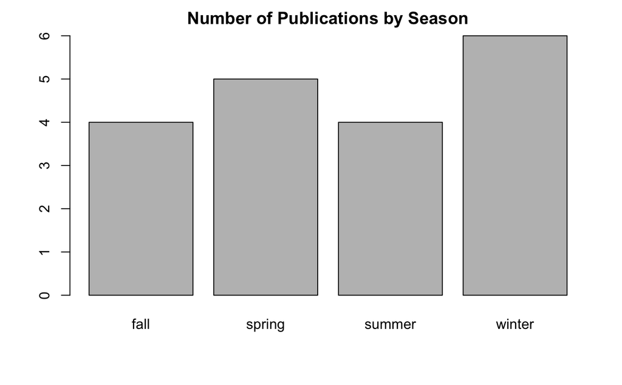

```r
barplot(df_pubs_per_season$Publications, main = "Number of Publications by Season", names.arg = c(df_pubs_per_season$season))
```

Plot time spent per season

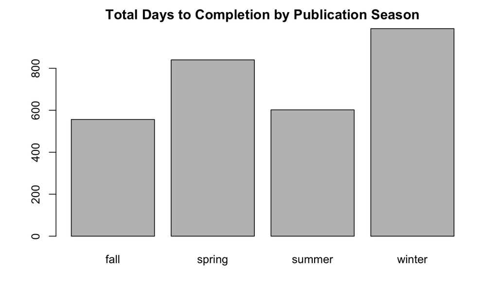

```r
barplot(df_time_per_season$Days, main = "Total Days to Completion by Publication Season", names.arg = c(df_time_per_season$season))
```

Plot authors publishing per season

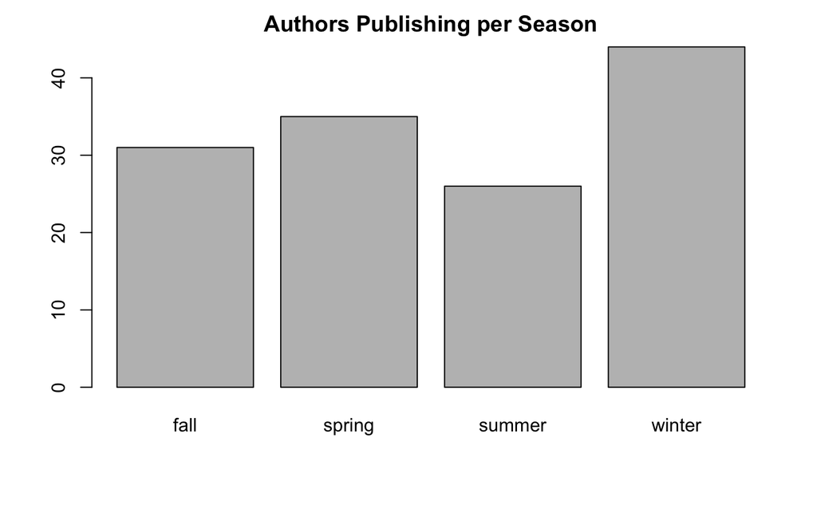

```r
barplot(df_author_per_season$Authors, main = "Authors Publishing per Season", names.arg = c(df_author_per_season$season))
```

Mazumdar’s publications by season

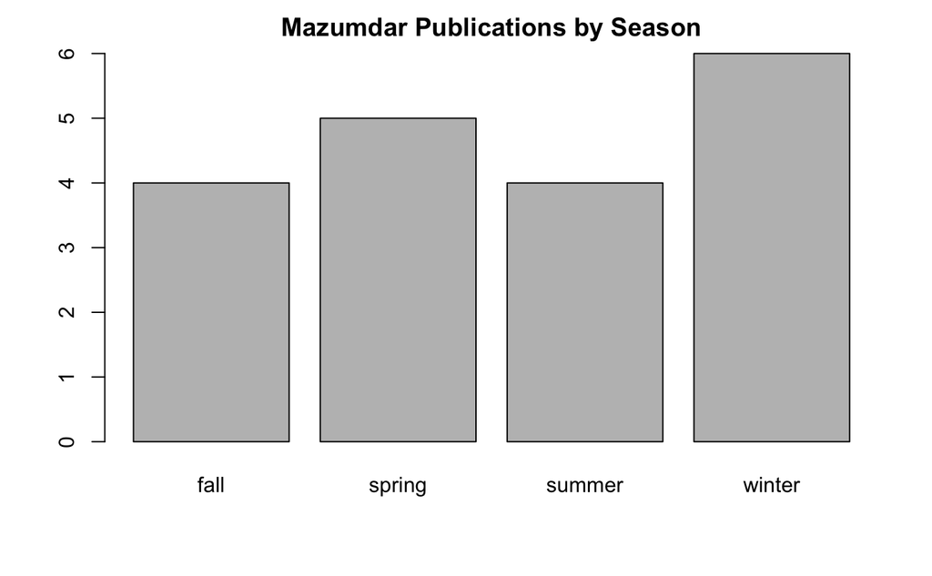

```r
barplot(df_mazumdar$Publications, main = "Mazumdar Publications by Season", names.arg = c(df_mazumdar$season))
```

Chiu’s days by season

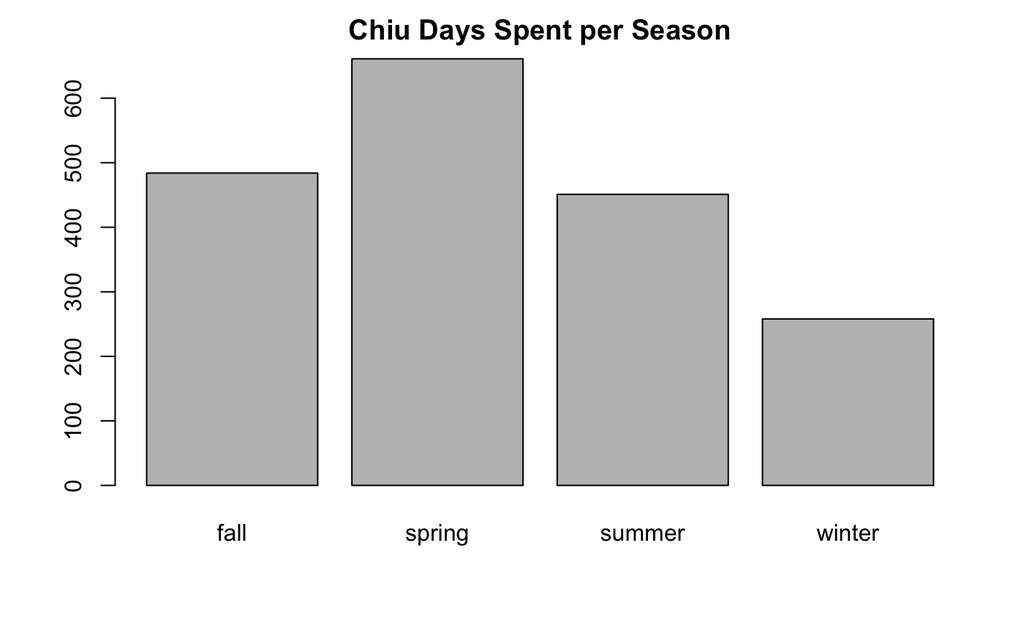

```r
barplot(df_chiu$Days, main = "Chiu Days Spent per Season", names.arg = c(df_chiu$season))
```

### Explanation

Querying the article fact table, we are able to more easily find the number of articles published per season, the total time spent on the articles by the season they were first published, and the number of authors publishing articles per season. Additional queries in the star schema could also allow us to find one author’s number of publications per season. For example, we chose to search for the number of publications the author with the last name Mazumdar published per season. We then used a similar query to find the amount of time that author with the last name Chiu spent publishing by season.

### Test to see if the database contain any data

Normalized Database Table Samples

```r
author = dbSendStatement(med, "Select * from author")
dbFetch(author)
```

| authorID | lastName | foreName | initial | affiliation |
| --- | --- | --- | --- | --- |
| 1 | Kuo | Cassie | C | Department of Anesthesiology, Hospital for Special Surgery, 535 East 70th Street, New York, NY 10021 USA. |
| 2 | Edwards | Alison | A |  |
| 3 | Mazumdar | Madhu | M |  |
| 4 | Memtsoudis | Stavros G | SG |  |
| 5 | Stundner | Ottokar | O | Department of Anesthesiology, Hospital for Special Surgery, Weill Medical College of Cornell University, New York, NY, USA. |
| 6 | Kirksey | Meghan | M |  |
| 7 | Chiu | Ya Lin | YL |  |
| 8 | Mazumdar | Madhu | M |  |
| 9 | Poultsides | Lazaros | L |  |
| 10 | Gerner | Peter | P |  |

[output cut: 126 more lines]

```r
author_article = dbSendStatement(med, "Select * from author_article")
dbFetch(author_article)
```

| authorID | articleID |
| --- | --- |
| 1 | 23874253 |
| 2 | 23874253 |
| 3 | 23874253 |
| 4 | 23874253 |
| 5 | 23194934 |
| 6 | 23194934 |
| 7 | 23194934 |
| 8 | 23194934 |
| 9 | 23194934 |
| 10 | 23194934 |

[output cut: 126 more lines]

```r
article = dbSendStatement(med, "Select * from article")
dbFetch(article)
```

| pmID | doi | abstract | articleTitle | pubModel | pubYear | pubMonth |
| --- | --- | --- | --- | --- | --- | --- |
| 23874253 | 10.1007/s11420-012-9278-8 | Our objective was to evaluate national trends in regional anesthetic techniques among children undergoing ambulatory orthopedic procedures.\|We aimed to determine whether an increase in regional anest… | Regional anesthesia for children undergoing orthopedic ambulatory surgeries in the United States, 1996-2006. | Print-Electronic | 2012 | Jul |
| 23194934 | 10.1016/j.psym.2012.08.009 | Depression and anxiety are highly prevalent psychiatric disorders. However, little is known about their impact on outcomes in the perioperative setting. This study is intended to gain insight into epi… | Demographics and perioperative outcome in patients with depression and anxiety undergoing total joint arthroplasty: a population-based study. | Print-Electronic |  |  |
| 23091119 | 10.1161/STROKEAHA.112.663716 | Impairments in cerebrovascular reserve (CVR) have been variably associated with increased risk of ischemic events and may stratify stroke risk in patients with high-grade internal carotid artery steno… | Cerebrovascular reserve and stroke risk in patients with carotid stenosis or occlusion: a systematic review and meta-analysis. | Print | 2012 | Nov |
| 23080348 | 10.1097/AAP.0b013e31826e1494 | The influence of the type of anesthesia on perioperative outcomes after bilateral total knee arthroplasty (BTKA) remains unknown. Therefore, we examined a large sample of BTKA recipients, hypothesizin… | Comparative perioperative outcomes associated with neuraxial versus general anesthesia for simultaneous bilateral total knee arthroplasty. | Print |  |  |
| 23068970 | 10.1016/j.seizure.2012.09.014 | Lennox-Gastaut syndrome (LGS) is an epileptogenic disorder that arises in childhood and is typically characterized by multiple seizure types, slow spike-and-wave complexes on EEG and cognitive impairm… | Vagus nerve stimulation vs. corpus callosotomy in the treatment of Lennox-Gastaut syndrome: a meta-analysis. | Print-Electronic | 2013 | Jan |
| 23008025 | 10.1007/s11999-012-2608-9 | Studies suggest a trend in the selection of younger and healthier individuals to undergo bilateral TKAs in an attempt to diminish the incidence of complications. It remains unclear whether this develo… | Have bilateral total knee arthroplasties become safer? A population-based trend analysis. | Print-Electronic | 2013 | Jan |
| 22677144 | 10.1016/j.arth.2012.04.011 | We evaluated the impact of metabolic syndrome (MetS) on perioperative outcomes in patients undergoing total joint arthroplasty. Using the Nationwide Inpatient Sample, patients with MetS were identifie… | The metabolic syndrome in patients undergoing knee and hip arthroplasty: trends and in-hospital outcomes in the United States. | Print-Electronic | 2012 | Dec |
| 22634871 | 10.1097/ALN.0b013e31825afd36 | A paucity of data exist on the use of critical care services (CCS) among hip and knee arthroplasty patients. The authors sought to identify the incidence and risk factors for the use of CCS among thes… | Utilization of critical care services among patients undergoing total hip and knee arthroplasty: epidemiology and risk factors. | Print | 2012 | Jul |
| 22434554 | 10.1007/s00247-012-2377-3 | Magnetic resonance (MR) imaging may provide a radiation-sparing alternative to CT in diagnosing appendicitis in children in whom US is equivocal. However, comparability with CT in the detection of the… | Visualization of the normal appendix with MR enterography in children. | Print-Electronic | 2012 | Aug |
| 22426260 | 10.1097/DCR.0b013e318244a666 | At present there is no defined role for routine FDG-PET in the preoperative evaluation of nonmetastatic rectal cancer.\|The primary objective of this study was to evaluate the ability of FDG-PET to pr… | FDG-PET assessment of rectal cancer response to neoadjuvant chemoradiotherapy is not associated with long-term prognosis: a prospective evaluation. | Print | 2012 | Apr |

[output cut: 9 more lines]

```r
article_journal = dbSendStatement(med, "Select * from article_journal")
dbFetch(article_journal)
```

| journalID | articleID | volume | issue | medLinePGN |
| --- | --- | --- | --- | --- |
| 1 | 23874253 | 8 | 2 | 133-6 |
| 2 | 23194934 | 54 | 2 | 149-57 |
| 3 | 23091119 | 43 | 11 | 2884-91 |
| 4 | 23080348 | 37 | 6 | 638-44 |
| 5 | 23068970 | 22 | 1 | 3-8 |
| 6 | 23008025 | 471 | 1 | 17-25 |
| 7 | 22677144 | 27 | 10 | 1743-1749.e1 |
| 8 | 22634871 | 117 | 1 | 107-16 |
| 9 | 22434554 | 42 | 8 | 959-64 |
| 10 | 22426260 | 55 | 4 | 378-86 |

[output cut: 9 more lines]

```r
journal = dbSendStatement(med, "Select * from journal")
dbFetch(journal)
```

| journalID | issn | issnType | journal |
| --- | --- | --- | --- |
| 1 | 1556-3316 | Print | HSS J |
| 2 | 1545-7206 | Electronic | Psychosomatics |
| 3 | 1524-4628 | Electronic | Stroke |
| 4 | 1532-8651 | Electronic | Reg Anesth Pain Med |
| 5 | 1532-2688 | Electronic | Seizure |
| 6 | 1528-1132 | Electronic | Clin. Orthop. Relat. Res. |
| 7 | 1532-8406 | Electronic | J Arthroplasty |
| 8 | 1528-1175 | Electronic | Anesthesiology |
| 9 | 1432-1998 | Electronic | Pediatr Radiol |
| 10 | 1530-0358 | Electronic | Dis. Colon Rectum |

[output cut: 9 more lines]

```r
history = dbSendStatement(med, "Select * from history")
dbFetch(history)
```

| pmID | dateCreated | dateComplete | dateRevised | pmData |
| --- | --- | --- | --- | --- |
| 23874253 | 2013-07-22 | 2013-07-22 | 2013-07-22 | NA |
| 23194934 | 2013-03-04 | 2014-01-14 | 2014-01-14 | NA |
| 23091119 | 2012-10-23 | 2013-01-03 | 2013-01-03 | NA |
| 23080348 | 2012-10-24 | 2013-04-08 | 2013-04-08 | NA |
| 23068970 | 2013-01-14 | 2013-07-01 | 2013-07-01 | NA |
| 23008025 | 2012-12-24 | 2013-05-28 | 2013-05-28 | NA |
| 22677144 | 2012-11-13 | 2013-05-15 | 2013-05-15 | NA |
| 22634871 | 2012-06-21 | 2013-07-08 | 2013-07-08 | NA |
| 22434554 | 2012-08-09 | 2013-01-07 | 2013-01-07 | NA |
| 22426260 | 2012-03-19 | 2012-05-04 | 2012-05-04 | NA |

[output cut: 9 more lines]

Star Schema Table Samples

```r
n = dbSendStatement(pub, "Select * from author")
dbFetch(n)
```

| authorID | lastName | foreName | initial | affiliation |
| --- | --- | --- | --- | --- |
| 1 | Kuo | Cassie | C | Department of Anesthesiology, Hospital for Special Surgery, 535 East 70th Street, New York, NY 10021 USA. |
| 2 | Edwards | Alison | A |  |
| 3 | Mazumdar | Madhu | M |  |
| 4 | Memtsoudis | Stavros G | SG |  |
| 5 | Stundner | Ottokar | O | Department of Anesthesiology, Hospital for Special Surgery, Weill Medical College of Cornell University, New York, NY, USA. |
| 6 | Kirksey | Meghan | M |  |
| 7 | Chiu | Ya Lin | YL |  |
| 8 | Mazumdar | Madhu | M |  |
| 9 | Poultsides | Lazaros | L |  |
| 10 | Gerner | Peter | P |  |

[output cut: 126 more lines]

```r
article = dbSendStatement(pub, "Select * from articles")
dbFetch(article)
```

| pmID | dateTimeID | authorID | pubJournalID |
| --- | --- | --- | --- |
| 23874253 | 1 | 1 | 1 |
| 23874253 | 1 | 2 | 1 |
| 23874253 | 1 | 3 | 1 |
| 23874253 | 1 | 4 | 1 |
| 23194934 | 2 | 5 | 2 |
| 23194934 | 2 | 6 | 2 |
| 23194934 | 2 | 7 | 2 |
| 23194934 | 2 | 8 | 2 |
| 23194934 | 2 | 9 | 2 |
| 23194934 | 2 | 10 | 2 |

[output cut: 126 more lines]

```r
journal = dbSendStatement(pub, "Select * from journal")
dbFetch(journal)
```

| journalID | issn | issnType | journal |
| --- | --- | --- | --- |
| 1 | 1556-3316 | Print | HSS J |
| 2 | 1545-7206 | Electronic | Psychosomatics |
| 3 | 1524-4628 | Electronic | Stroke |
| 4 | 1532-8651 | Electronic | Reg Anesth Pain Med |
| 5 | 1532-2688 | Electronic | Seizure |
| 6 | 1528-1132 | Electronic | Clin. Orthop. Relat. Res. |
| 7 | 1532-8406 | Electronic | J Arthroplasty |
| 8 | 1528-1175 | Electronic | Anesthesiology |
| 9 | 1432-1998 | Electronic | Pediatr Radiol |
| 10 | 1530-0358 | Electronic | Dis. Colon Rectum |

[output cut: 9 more lines]

```r
history = dbSendStatement(pub, "Select * from history")
dbFetch(history)
```

| pmID | dateCreated | dateComplete | dateRevised | pmData |
| --- | --- | --- | --- | --- |
| 23874253 | 2013-07-22 | 2013-07-22 | 2013-07-22 | NA |
| 23194934 | 2013-03-04 | 2014-01-14 | 2014-01-14 | NA |
| 23091119 | 2012-10-23 | 2013-01-03 | 2013-01-03 | NA |
| 23080348 | 2012-10-24 | 2013-04-08 | 2013-04-08 | NA |
| 23068970 | 2013-01-14 | 2013-07-01 | 2013-07-01 | NA |
| 23008025 | 2012-12-24 | 2013-05-28 | 2013-05-28 | NA |
| 22677144 | 2012-11-13 | 2013-05-15 | 2013-05-15 | NA |
| 22634871 | 2012-06-21 | 2013-07-08 | 2013-07-08 | NA |
| 22434554 | 2012-08-09 | 2013-01-07 | 2013-01-07 | NA |
| 22426260 | 2012-03-19 | 2012-05-04 | 2012-05-04 | NA |

[output cut: 9 more lines]

```r
article_fact = dbSendStatement(pub, "Select * from article_fact")
dbFetch(article_fact)
```

| pmID | pubJournalID | numAuthors | timeToComplete | season |
| --- | --- | --- | --- | --- |
| 21301391 | 19 | 6 | 258 | winter |
| 21778465 | 18 | 6 | 135 | fall |
| 21851550 | 17 | 11 | 63 | winter |
| 22020835 | 16 | 10 | 69 | summer |
| 22024892 | 15 | 7 | 119 | spring |
| 22115762 | 14 | 6 | 226 | spring |
| 22189576 | 13 | 3 | 221 | winter |
| 22235286 | 12 | 12 | 124 | winter |
| 22305625 | 11 | 6 | 133 | spring |
| 22426260 | 10 | 9 | 46 | spring |

[output cut: 9 more lines]

```r
dateTime = dbSendStatement(pub, "Select * from dateTime")
dbFetch(dateTime)
```

| dateTimeID | quarter | year |
| --- | --- | --- |
| 1 | 07 | 2013 |
| 2 | 03 | 2013 |
| 3 | 10 | 2012 |
| 4 | 10 | 2012 |
| 5 | 01 | 2013 |
| 6 | 12 | 2012 |
| 7 | 11 | 2012 |
| 8 | 06 | 2012 |
| 9 | 08 | 2012 |
| 10 | 03 | 2012 |

[output cut: 9 more lines]

```r
article_journal = dbSendStatement(pub, "Select * from article_journal")
dbFetch(article_journal)
```

| journalID | volume | issue | medLinePGN |
| --- | --- | --- | --- |
| 1 | 8 | 2 | 133-6 |
| 2 | 54 | 2 | 149-57 |
| 3 | 43 | 11 | 2884-91 |
| 4 | 37 | 6 | 638-44 |
| 5 | 22 | 1 | 3-8 |
| 6 | 471 | 1 | 17-25 |
| 7 | 27 | 10 | 1743-1749.e1 |
| 8 | 117 | 1 | 107-16 |
| 9 | 42 | 8 | 959-64 |
| 10 | 55 | 4 | 378-86 |

[output cut: 9 more lines]

```r
article_data = dbSendStatement(pub, "Select * from articleData")
dbFetch(article_data)
```

| pmID | doi | abstract | articleTitle | pubModel | pubYear | pubMonth |
| --- | --- | --- | --- | --- | --- | --- |
| 23874253 | 10.1007/s11420-012-9278-8 | Our objective was to evaluate national trends in regional anesthetic techniques among children undergoing ambulatory orthopedic procedures.\|We aimed to determine whether an increase in regional anest… | Regional anesthesia for children undergoing orthopedic ambulatory surgeries in the United States, 1996-2006. | Print-Electronic | 2012 | Jul |
| 23194934 | 10.1016/j.psym.2012.08.009 | Depression and anxiety are highly prevalent psychiatric disorders. However, little is known about their impact on outcomes in the perioperative setting. This study is intended to gain insight into epi… | Demographics and perioperative outcome in patients with depression and anxiety undergoing total joint arthroplasty: a population-based study. | Print-Electronic |  |  |
| 23091119 | 10.1161/STROKEAHA.112.663716 | Impairments in cerebrovascular reserve (CVR) have been variably associated with increased risk of ischemic events and may stratify stroke risk in patients with high-grade internal carotid artery steno… | Cerebrovascular reserve and stroke risk in patients with carotid stenosis or occlusion: a systematic review and meta-analysis. | Print | 2012 | Nov |
| 23080348 | 10.1097/AAP.0b013e31826e1494 | The influence of the type of anesthesia on perioperative outcomes after bilateral total knee arthroplasty (BTKA) remains unknown. Therefore, we examined a large sample of BTKA recipients, hypothesizin… | Comparative perioperative outcomes associated with neuraxial versus general anesthesia for simultaneous bilateral total knee arthroplasty. | Print |  |  |
| 23068970 | 10.1016/j.seizure.2012.09.014 | Lennox-Gastaut syndrome (LGS) is an epileptogenic disorder that arises in childhood and is typically characterized by multiple seizure types, slow spike-and-wave complexes on EEG and cognitive impairm… | Vagus nerve stimulation vs. corpus callosotomy in the treatment of Lennox-Gastaut syndrome: a meta-analysis. | Print-Electronic | 2013 | Jan |
| 23008025 | 10.1007/s11999-012-2608-9 | Studies suggest a trend in the selection of younger and healthier individuals to undergo bilateral TKAs in an attempt to diminish the incidence of complications. It remains unclear whether this develo… | Have bilateral total knee arthroplasties become safer? A population-based trend analysis. | Print-Electronic | 2013 | Jan |
| 22677144 | 10.1016/j.arth.2012.04.011 | We evaluated the impact of metabolic syndrome (MetS) on perioperative outcomes in patients undergoing total joint arthroplasty. Using the Nationwide Inpatient Sample, patients with MetS were identifie… | The metabolic syndrome in patients undergoing knee and hip arthroplasty: trends and in-hospital outcomes in the United States. | Print-Electronic | 2012 | Dec |
| 22634871 | 10.1097/ALN.0b013e31825afd36 | A paucity of data exist on the use of critical care services (CCS) among hip and knee arthroplasty patients. The authors sought to identify the incidence and risk factors for the use of CCS among thes… | Utilization of critical care services among patients undergoing total hip and knee arthroplasty: epidemiology and risk factors. | Print | 2012 | Jul |
| 22434554 | 10.1007/s00247-012-2377-3 | Magnetic resonance (MR) imaging may provide a radiation-sparing alternative to CT in diagnosing appendicitis in children in whom US is equivocal. However, comparability with CT in the detection of the… | Visualization of the normal appendix with MR enterography in children. | Print-Electronic | 2012 | Aug |
| 22426260 | 10.1097/DCR.0b013e318244a666 | At present there is no defined role for routine FDG-PET in the preoperative evaluation of nonmetastatic rectal cancer.\|The primary objective of this study was to evaluate the ability of FDG-PET to pr… | FDG-PET assessment of rectal cancer response to neoadjuvant chemoradiotherapy is not associated with long-term prognosis: a prospective evaluation. | Print | 2012 | Apr |

[output cut: 9 more lines]